# World Value Survey Analysis

10/17/2019

## What the World Values Survey Is

> -an international to study how people's values change over time and the resulting impact on political and social aspects of a country

> -distributed in nearly 100 countries

> -explore the participants' views on democracy, tolerance, gender and race equality, religion, the environment, politics, famility, the community, etc

> -data that can be analyzed to understand how people's beliefs, motivations, and values evolve between countries and over time and providing key insights to a multitude of different questions

## Goals for this Project

> -performed simple Exploratory Data Analysis on WVS data sets from the United States, Russia, and Japan

> -compared responses for individual questions and proportion of responses for pairs of variables

> -explored differences in the survey questions that were asked among the three countries

## Cleaning

> -removing columns with repetative, no longer necessary information

> -questions that were not asked in each country were identified, saved to vectors by name, and deleted from the main data frame

> -find the union of all questions asked, intersections among the combinations of countries, and questions unique for each country

> -each column of the data sets were set to be factors and reordered when necessary

## Single Variable Graphs

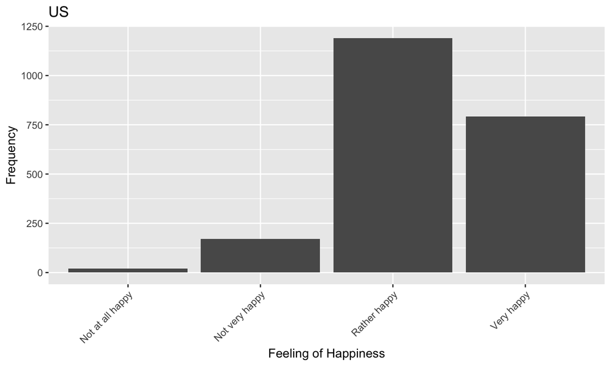

## Single Variable Graphs

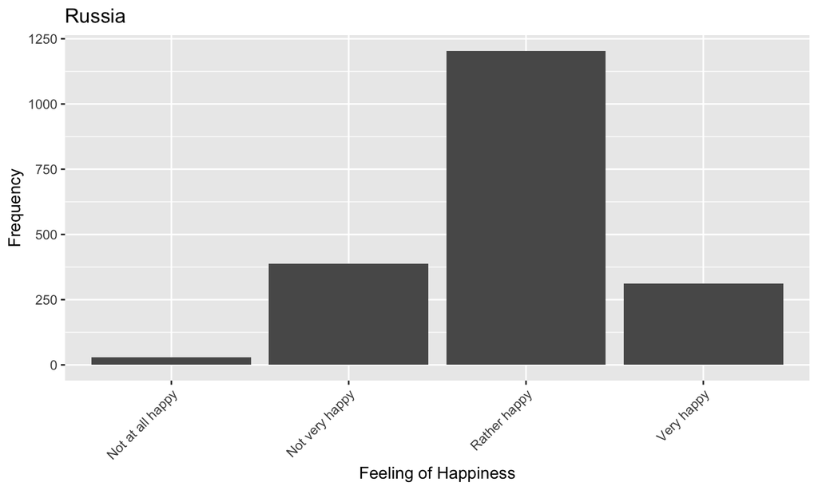

## Single Variable Graphs

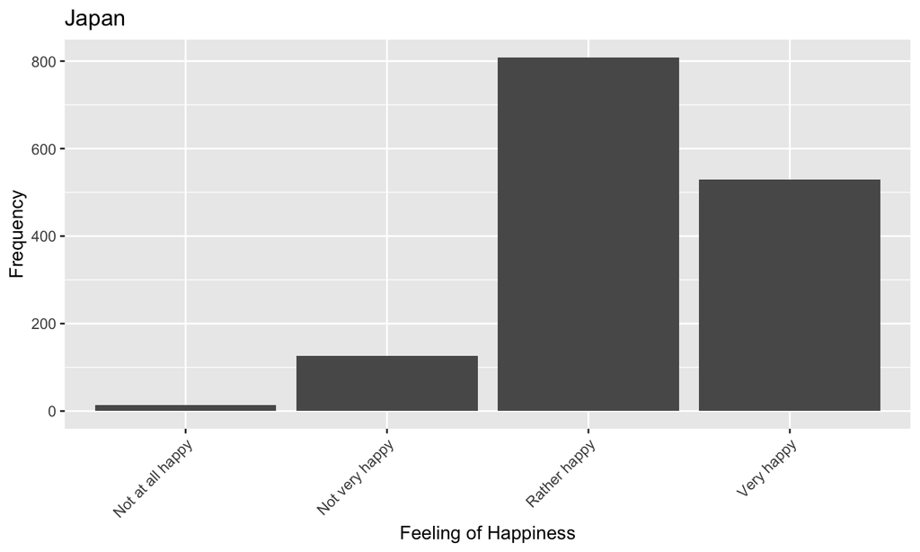

## Single Variable Graphs

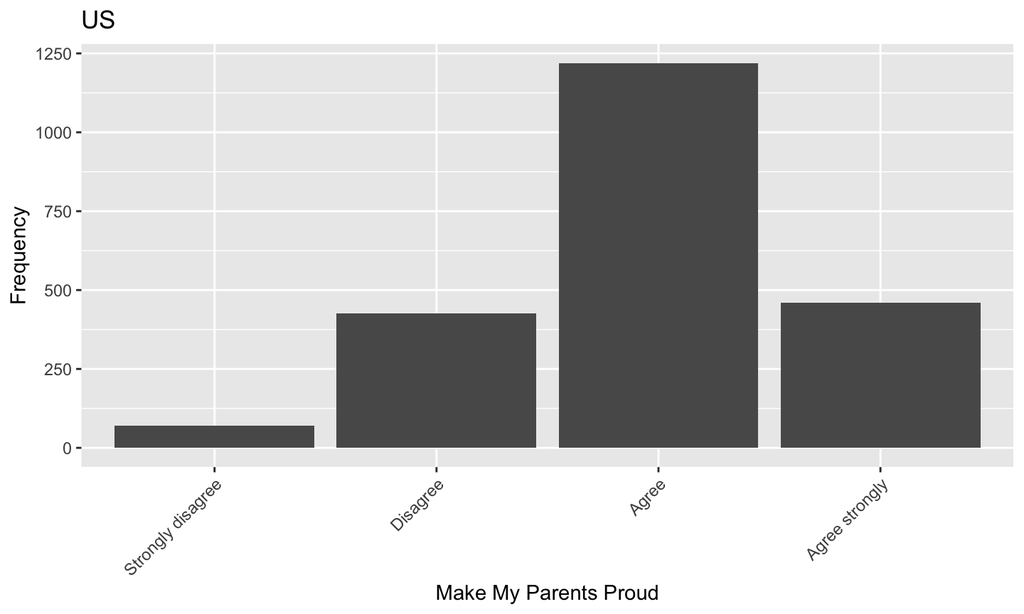

## Single Variable Graphs

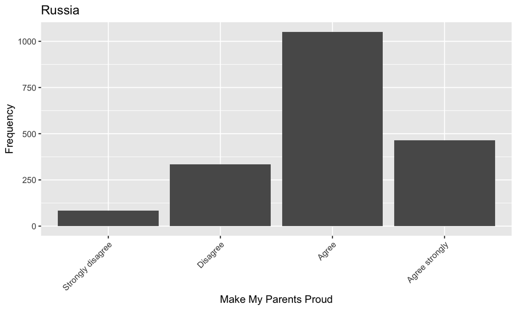

## Single Variable Graphs

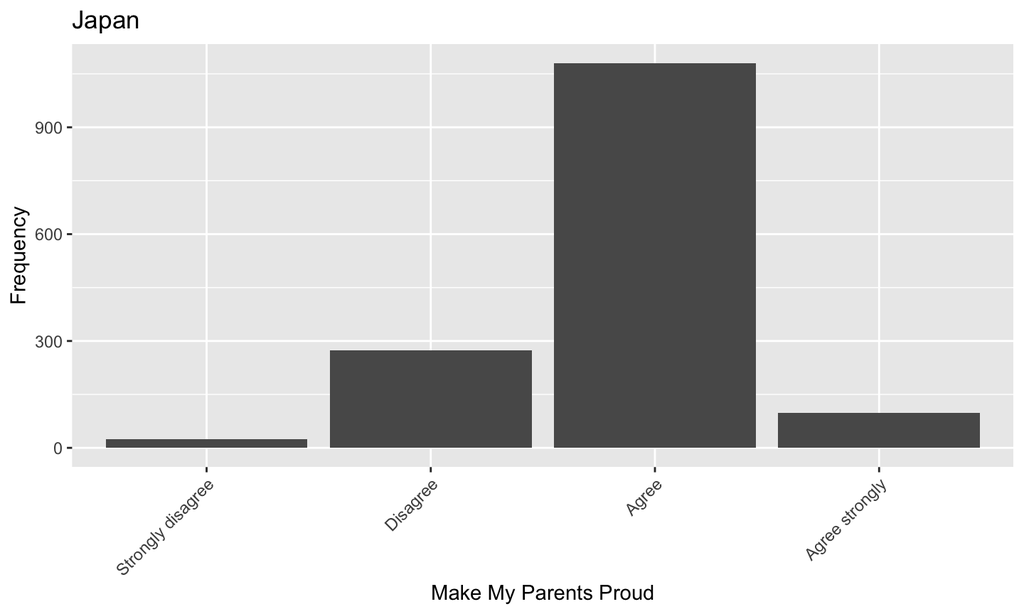

## Single Variable Graphs

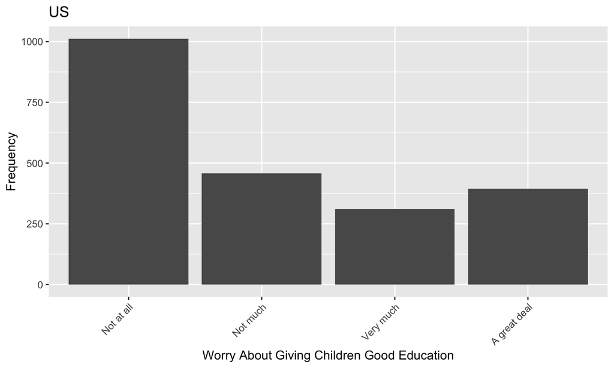

## Single Variable Graphs

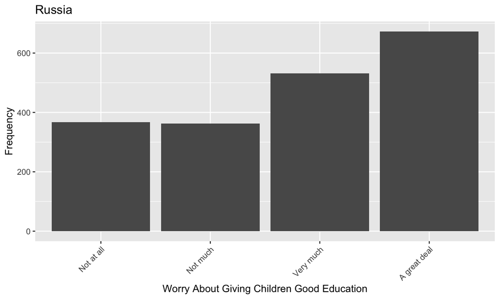

## Single Variable Graphs

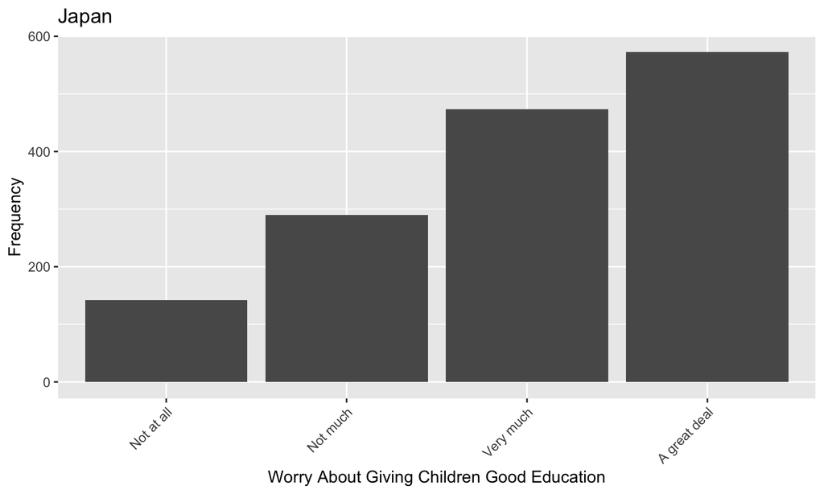

## Double Variable Graphs - Happiness and Proud Parents

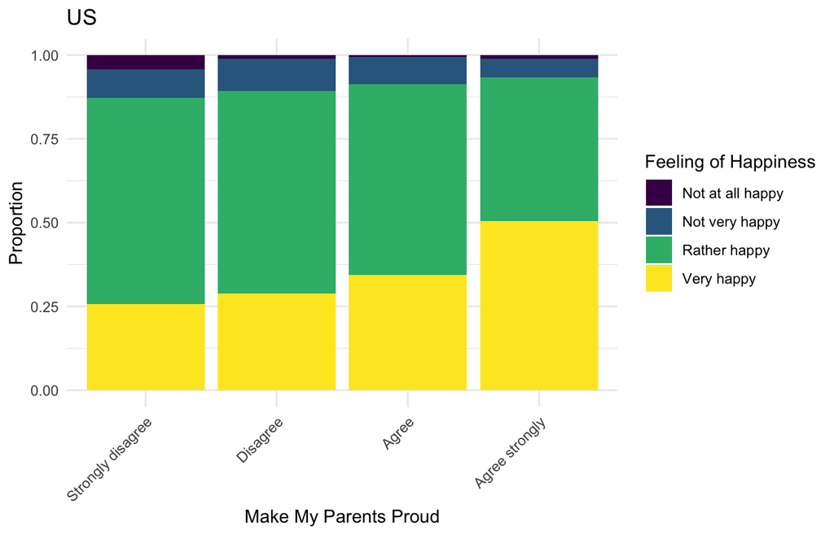

## Double Variable Graphs - Happiness and Proud Parents

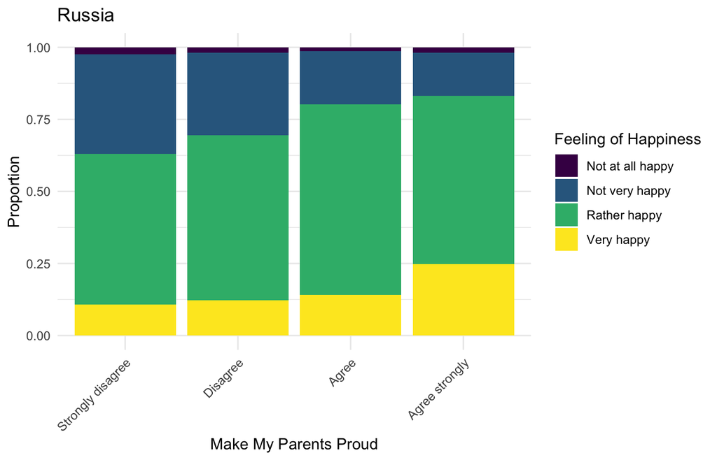

## Double Variable Graphs - Happiness and Proud Parents

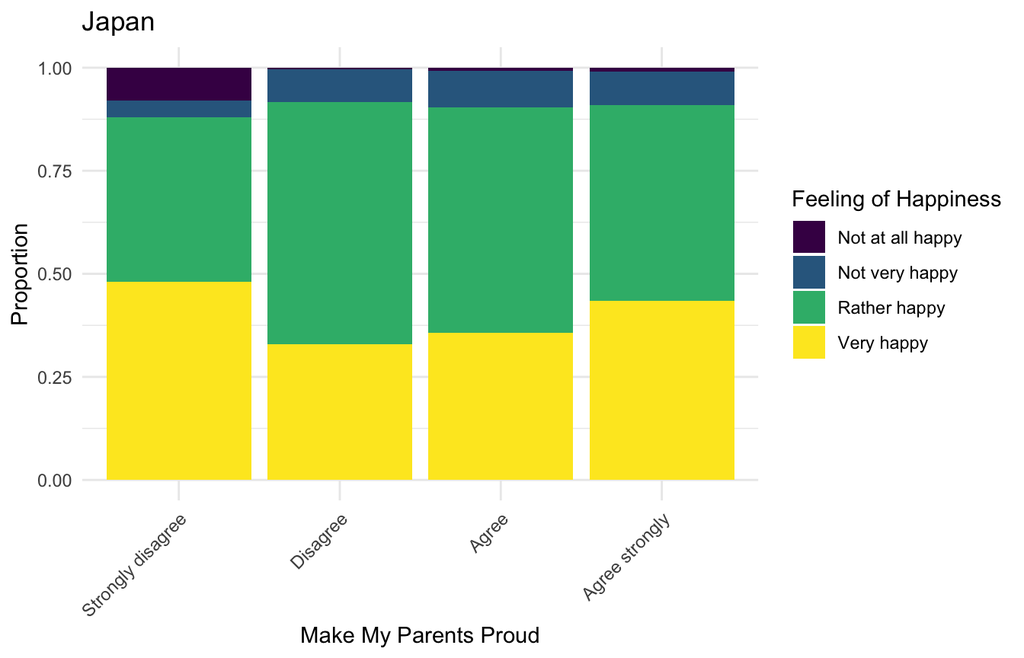

## Double Variable Graphs - Happiness and Worries

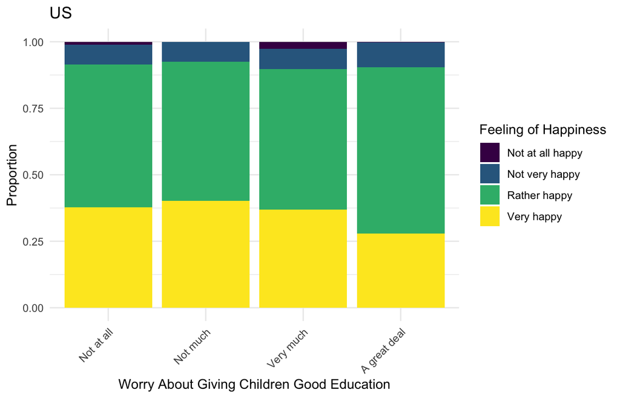

## Double Variable Graphs - Happiness and Worries

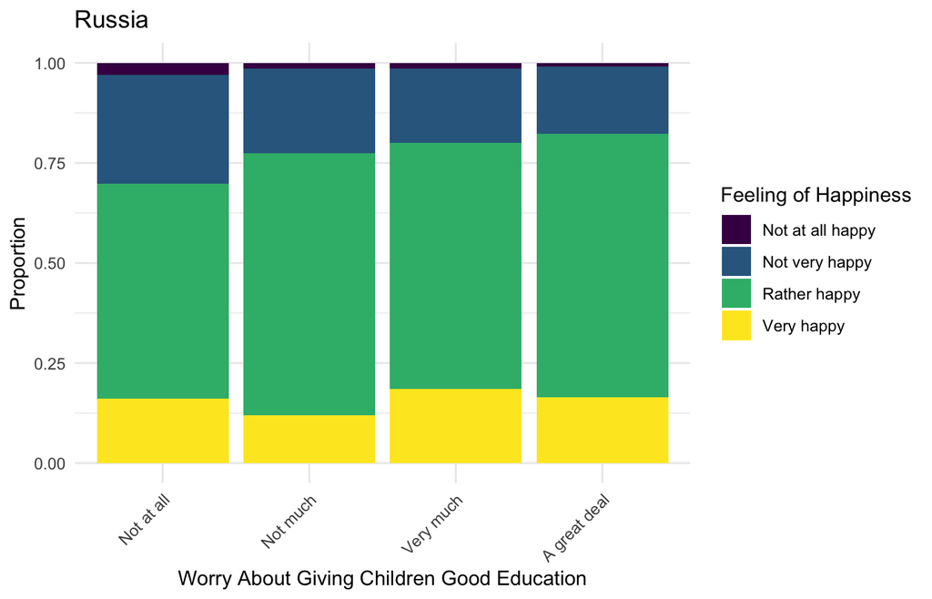

## Double Variable Graphs - Happiness and Worries

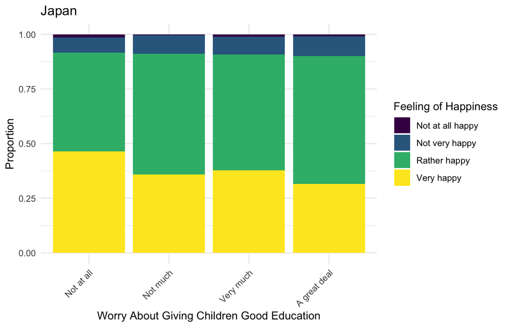

## Question Sets

Not Asked Observations: >- logically excluded such as a person’s confidence level on certain organizations that the three countries are not members since those do not pertain to those three countries

- additional personality traits, election integrity and government corruption inquiries

Unique US: appropriate for the only North American country in the data set

Unique Russia: two of three relate to the Commonwealth of Independent States (CIS); third was prostitution

Unique Japan: additional questions specifically over the Aisan concerns; last was “It is important to this person to do something good for society”

## The End

**Questions?**